# Appendix: K-Means and Agglomerative Clustering

**"De-Fault" Words in Our Stars: Theme extraction through clustering n-starred Amazon.com reviews**

This notebook contains codes and results for clustering Amazon.com reviews using methods such as k-Means and agglomerative method. Codes for data preprocessing similar to the main notebook is included to maintain the characteristics of the processed data.

### Setting up libraries

```python
import pandas as pd
import numpy as np
import matplotlib.pyplot as plt
import re
from collections import Counter
from wordcloud import STOPWORDS, WordCloud
from sklearn.feature_extraction.text import TfidfVectorizer
from sklearn.manifold import TSNE
from sklearn.decomposition import TruncatedSVD
from sklearn.cluster import KMeans
from scipy.cluster.hierarchy import linkage, dendrogram, fcluster
from sklearn.cluster import AgglomerativeClustering
```

### Loading the dataset

```python
raw = pd.read_csv("amazon_reviews.csv")
```

```python
print("Data dimensions: {}".format(raw.shape))
print("Missing values: {}".format(raw.isnull().sum().sum()))
raw.head()
```

```
Data dimensions: (12128, 3)
Missing values: 0
```

|  | product_id | star_rating | reviews |
| --- | --- | --- | --- |
| 0 | B00OYRW4UE | 5 | Exactly as described. Good quality. Shipped fast |
| 1 | B0000537JQ | 5 | It is great |
| 2 | B00HXXO332 | 5 | It's really nice it works great. You have the ... |
| 3 | B00EOB0JA2 | 2 | The kit works fine... simple cheap plastic tho |
| 4 | B00OC2O1UC | 4 | It works better than anything else ive tried |

### Data Pre-Processing

```python
stopwords= set(['br', 'the', 'i', 'me', 'my', 'myself', 'we', 'our', 'ours', 'ourselves', 'you', "you're", "you've",\
            "you'll", "you'd", 'your', 'yours', 'yourself', 'yourselves', 'he', 'him', 'his', 'himself', \
            'she', "she's", 'her', 'hers', 'herself', 'it', "it's", 'its', 'itself', 'they', 'them', 'their',\
            'theirs', 'themselves', 'what', 'which', 'who', 'whom', 'this', 'that', "that'll", 'these', 'those', \
            'am', 'is', 'are', 'was', 'were', 'be', 'been', 'being', 'have', 'has', 'had', 'having', 'do', 'does', \
            'did', 'doing', 'a', 'an', 'the', 'and', 'but', 'if', 'or', 'because', 'as', 'until', 'while', 'of', \
            'at', 'by', 'for', 'with', 'about', 'against', 'between', 'into', 'through', 'during', 'before', 'after',\
            'above', 'below', 'to', 'from', 'up', 'down', 'in', 'out', 'on', 'off', 'over', 'under', 'again', 'further',\
            'then', 'once', 'here', 'there', 'when', 'where', 'why', 'how', 'all', 'any', 'both', 'each', 'few', 'more',\
            'most', 'other', 'some', 'such', 'only', 'own', 'same', 'so', 'than', 'too', 'very', \
            's', 't', 'can', 'will', 'just', 'don', "don't", 'should', "should've", 'now', 'd', 'll', 'm', 'o', 're', \
            've', 'y', 'ain', 'aren', "aren't", 'couldn', "couldn't", 'didn', "didn't", 'doesn', "doesn't", 'hadn',\
            "hadn't", 'hasn', "hasn't", 'haven', "haven't", 'isn', "isn't", 'ma', 'mightn', "mightn't", 'mustn',\
            "mustn't", 'needn', "needn't", 'shan', "shan't", 'shouldn', "shouldn't", 'wasn', "wasn't", 'weren', "weren't", \
            'won', "won't", 'wouldn', "wouldn't"])

stopwords = stopwords.union(set(STOPWORDS))
stopwords = stopwords.union(set(["book", "one", "product"]))
```

```python
def decontracted(phrase):
    # specific
    phrase = re.sub(r"won't", "will not", phrase)
    phrase = re.sub(r"can\'t", "can not", phrase)

    # general
    phrase = re.sub(r"n\'t", " not", phrase)
    phrase = re.sub(r"\'re", " are", phrase)
    phrase = re.sub(r"\'s", " is", phrase)
    phrase = re.sub(r"\'d", " would", phrase)
    phrase = re.sub(r"\'ll", " will", phrase)
    phrase = re.sub(r"\'t", " not", phrase)
    phrase = re.sub(r"\'ve", " have", phrase)
    phrase = re.sub(r"\'m", " am", phrase)
    return phrase
```

```python
df = raw.copy()

from tqdm import tqdm
preprocessed_reviews = []
# tqdm is for printing the status bar
for review in tqdm(df['reviews'].values):
    review = re.sub(r"&amp", '', review)
    review = re.sub(r"http\S+", "", review) # Removing http tags
    review = decontracted(review) # removing based on above functions
    review = re.sub("\S*\d\S*", " ", review).strip() # Removing alphanumeric
    review = re.sub('[^A-Za-z]+', ' ', review) # removing special characters
    review = ' '.join(e.lower() for e in review.split() if e.lower() not in stopwords)
#     review = get_lemmatized(review)
    preprocessed_reviews.append(review.strip())
```

```python
df['reviews'] = preprocessed_reviews
```

```python
ratings = []
for star in df.star_rating:
    if star < 3:
        rating = 'low'
    if star == 3:
        rating = 'neutral'
    if star > 3:
        rating = 'high'
    ratings.append(rating)
df['ratings'] = ratings
```

```python
low_group = df.groupby('ratings').get_group('low')
neutral_group = df.groupby('ratings').get_group('neutral')
high_group = df.groupby('ratings').get_group('high')
```

### Data Vectorization

```python
# Low-rated
tfidf_low = TfidfVectorizer(token_pattern=r'[a-z-]+',
                                   stop_words='english',
                                   ngram_range=(2,2),
                                   min_df=2)
bow_low = tfidf_low.fit_transform(list(low_group.reviews))
nonzeros = bow_low.sum(axis=1).nonzero()[0]
bow_low = bow_low[nonzeros]
reviews_low = low_group.iloc[nonzeros,:].reviews

#Neutral-rated
tfidf_neutral = TfidfVectorizer(token_pattern=r'[a-z-]+',
                                   stop_words='english',
                                   ngram_range=(2,2),
                                   min_df=2)
bow_neutral = tfidf_neutral.fit_transform(list(neutral_group.reviews))
nonzeros = bow_neutral.sum(axis=1).nonzero()[0]
bow_neutral = bow_neutral[nonzeros]
reviews_neutral = neutral_group.iloc[nonzeros,:].reviews

#High-rated
tfidf_high = TfidfVectorizer(token_pattern=r'[a-z-]+',
                                   stop_words='english',
                                   ngram_range=(2,2),
                                   min_df=2)
bow_high = tfidf_high.fit_transform(list(high_group.reviews))
nonzeros = bow_high.sum(axis=1).nonzero()[0]
bow_high = bow_high[nonzeros]
reviews_high = high_group.iloc[nonzeros,:].reviews


k_low = 5
k_neutral = 5
k_high = 5
```

# I. K-Means Clustering

The following k-means clustering uses five clusters following the optimal number of clusters identified in the internal validation criteria discussed in Notebook 2. Reviews per star rating underwent dimension reduction using TruncatedSVD at 80% variance explained. TSNE visualization of the results of the k-means clustering appear to have unparsimonious, unclear, unbalanced and less compact clusters relative to the results of the NMF clustering. Hence, k-means clustering was not considered as the model for our final clustering.

## 1. k-Means Clustering: Low-Rated Reviews

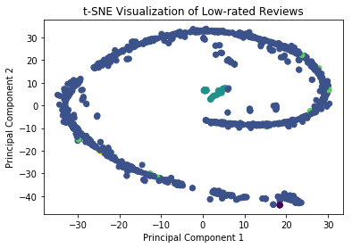

```python
lsa = TruncatedSVD(int(bow_low.shape[1])-1)
low_lsa = lsa.fit_transform(bow_low)
var = lsa.explained_variance_ratio_
c_var = var.cumsum()
n_comp = np.searchsorted(lsa.explained_variance_ratio_.cumsum(), 0.8) + 1

lsa = TruncatedSVD(n_components = n_comp)
low_lsa = lsa.fit_transform(bow_low)

kmeans = KMeans(n_clusters=5, max_iter=1000, algorithm = 'auto')

kmeans_transform_low = kmeans.fit_transform(low_lsa)
tsne_low = TSNE(random_state=1208).fit_transform(kmeans_transform_low)

prediction = kmeans.fit_predict(low_lsa)
plt.scatter(tsne_low[:, 0], tsne_low[:, 1], c=prediction)
plt.xlabel('Principal Component 1')
plt.ylabel('Principal Component 2')
plt.title('t-SNE Visualization of Low-rated Reviews');
```

## 2. k-Means Clustering: Neutral-Rated Reviews

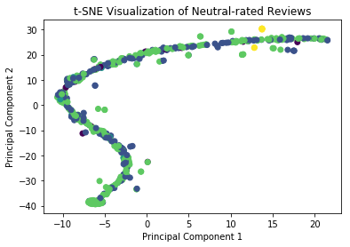

```python
lsa = TruncatedSVD(int(bow_neutral.shape[1])-1)
neutral_lsa = lsa.fit_transform(bow_neutral)
var = lsa.explained_variance_ratio_
c_var = var.cumsum()

n_comp = np.searchsorted(lsa.explained_variance_ratio_.cumsum(), 0.8) + 1

lsa = TruncatedSVD(n_components = n_comp)
neutral_lsa = lsa.fit_transform(bow_neutral)

kmeans = KMeans(n_clusters=5, max_iter=1000, algorithm = 'auto')
kmeans_transform_neutral = kmeans.fit_transform(neutral_lsa)
tsne_neutral = TSNE(random_state=1208).fit_transform(kmeans_transform_neutral)

prediction = kmeans.fit_predict(neutral_lsa)
plt.scatter(tsne_neutral[:, 0], tsne_neutral[:, 1], c=prediction)
plt.xlabel('Principal Component 1')
plt.ylabel('Principal Component 2')
plt.title('t-SNE Visualization of Neutral-rated Reviews');
```

## 3. k-Means Clustering: High-Rated Reviews

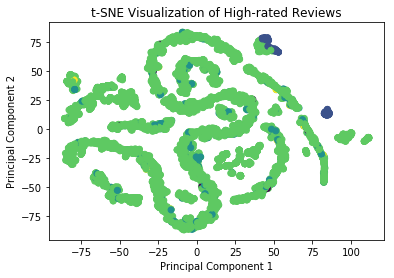

```python
lsa = TruncatedSVD(int(bow_high.shape[1])-1)
high_lsa = lsa.fit_transform(bow_high)
var = lsa.explained_variance_ratio_
c_var = var.cumsum()

n_comp = np.searchsorted(lsa.explained_variance_ratio_.cumsum(), 0.8) + 1

lsa = TruncatedSVD(n_components = n_comp)
high_lsa = lsa.fit_transform(bow_high)

kmeans = KMeans(n_clusters=5, max_iter=1000, algorithm = 'auto')

kmeans_transform_high = kmeans.fit_transform(high_lsa)
tsne_high = TSNE(random_state=1208).fit_transform(kmeans_transform_high)

prediction = kmeans.fit_predict(high_lsa)
plt.scatter(tsne_high[:, 0], tsne_high[:, 1], c=prediction)
plt.xlabel('Principal Component 1')
plt.ylabel('Principal Component 2')
plt.title('t-SNE Visualization of High-rated Reviews');
```

# II. Agglomerative Clustering: Complete Linkage Method

Below are results of the agglomerative clustering of Amazon reviews using the complete linkage method. The dendograms show 4, 5, and 5 clusters for low-rated, neutral-rated and high rated reviews, respectively. TSNE visualization of the clusters show no distinct, compact and balanced clustering. Hemce, agglomerative clustering was not considered as the best model for extracting themes from amazon.com reviews.

## 1. Low-Rated Reviews

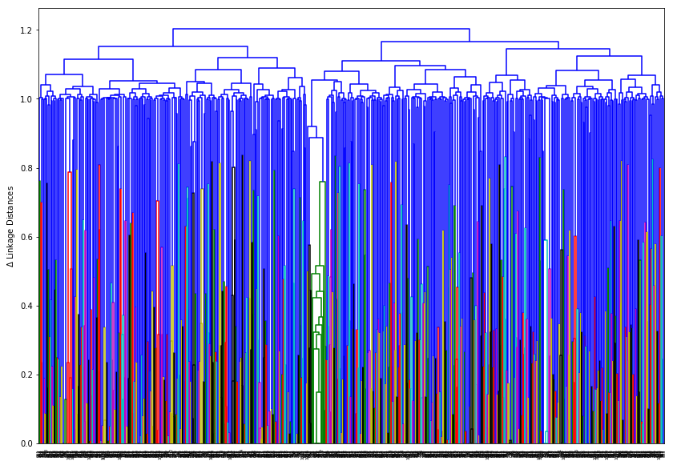

```python
Z_low = linkage(low_lsa, method='complete', optimal_ordering=True, metric='cosine')
fig, ax = plt.subplots(figsize=(14,10))
dn_low = dendrogram(Z_low, ax=ax, truncate_mode="level")
# ax.axhline(tolerance, linestyle='-.')
ax.set_ylabel(r'$\Delta$ Linkage Distances');
```

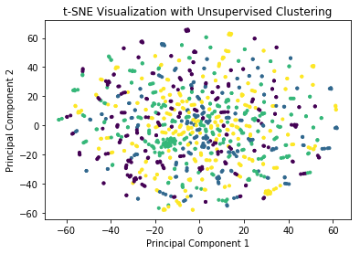

```python
k = 4
tolerance = sorted(Z_low[:,2], reverse=True)[k-1]
predict = fcluster(Z_low, t=tolerance, criterion='distance')

agg = AgglomerativeClustering(n_clusters=5)

# agg_transform_low = agg.fit_transform(low_lsa)
low_lsa_predict = agg.fit_predict(low_lsa)
tsne_low = TSNE(random_state=1208).fit_transform(low_lsa)

plt.scatter(tsne_low[:,0], tsne_low[:,1], marker='.', c=predict);
plt.xlabel('Principal Component 1')
plt.ylabel('Principal Component 2')
plt.title('t-SNE Visualization with Unsupervised Clustering');
```

## 2. Neutral-Rated Reviews

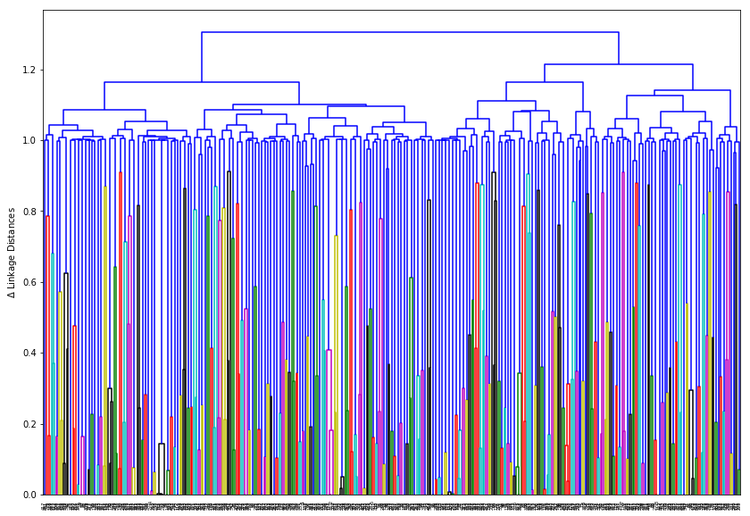

```python
Z_neutral = linkage(neutral_lsa, method='complete', optimal_ordering=True, metric='cosine')
fig, ax = plt.subplots(figsize=(14,10))
dn_neutral = dendrogram(Z_neutral, ax=ax, truncate_mode="level")
# ax.axhline(tolerance, linestyle='-.')
ax.set_ylabel(r'$\Delta$ Linkage Distances');
```

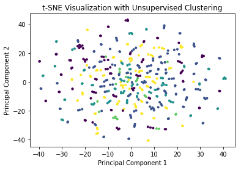

```python
k = 5
tolerance = sorted(Z_neutral[:,2], reverse=True)[k-1]
predict = fcluster(Z_neutral, t=tolerance, criterion='distance')

agg = AgglomerativeClustering(n_clusters=5)

# agg_transform_low = agg.fit_transform(low_lsa)
neutral_lsa_predict = agg.fit_predict(neutral_lsa)
tsne_neutral = TSNE(random_state=1208).fit_transform(neutral_lsa)

plt.scatter(tsne_neutral[:,0], tsne_neutral[:,1], marker='.', c=predict);
plt.xlabel('Principal Component 1')
plt.ylabel('Principal Component 2')
plt.title('t-SNE Visualization with Unsupervised Clustering');
```

## 3. High-Rated Reviews

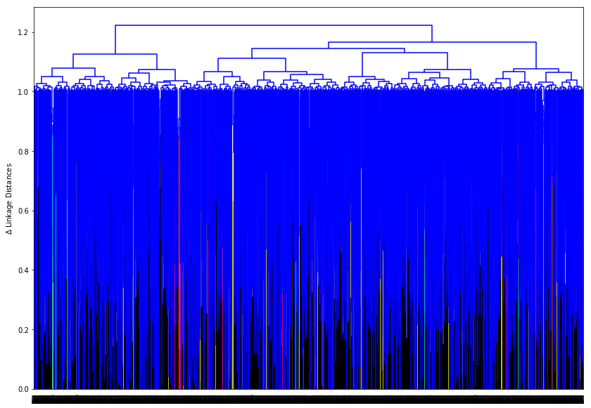

```python
Z_high = linkage(high_lsa, method='complete', optimal_ordering=True, metric='cosine')
fig, ax = plt.subplots(figsize=(14,10))
dn_high = dendrogram(Z_high, ax=ax, truncate_mode="level")
# ax.axhline(tolerance, linestyle='-.')
ax.set_ylabel(r'$\Delta$ Linkage Distances');
```

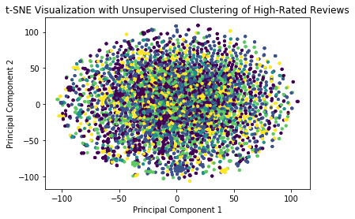

```python
k = 5
tolerance = sorted(Z_high[:,2], reverse=True)[k-1]
predict = fcluster(Z_high, t=tolerance, criterion='distance')

agg = AgglomerativeClustering(n_clusters=5)

# agg_transform_low = agg.fit_transform(low_lsa)
high_lsa_predict = agg.fit_predict(high_lsa)
tsne_high = TSNE(random_state=1208).fit_transform(high_lsa)

plt.scatter(tsne_high[:,0], tsne_high[:,1], marker='.', c=predict);
plt.xlabel('Principal Component 1')
plt.ylabel('Principal Component 2')
plt.title('t-SNE Visualization with Unsupervised Clustering of High-Rated Reviews');
```